# PIT Scanner Effectiveness and Seasonal Activity

Backwater Genetics Study — Yuma Cove and Imperial Ponds

B. Kesner

## Overview

Passive Integrated Transponder (PIT) antenna scanning provides continuous detection data for tagged fish within each backwater and pond. A detection on a given date confirms fish presence, but the absence of a detection during a deployment does not confirm absence or mortality — it may reflect reduced fish activity near the antenna, short deployment duration, or seasonal movement patterns.

This document characterizes how effectively PIT scanning detects fish that are known to be alive as a function of deployment effort and calendar month. Two methodological points are central to the analysis:

**Effort allocation.** A single effort record commonly spans multiple calendar months. Effort hours and the contacts associated with a given scanner unit (EID) must be allocated to the specific months in which they occurred. A scanner deployed March 12 through May 17 contributes hours — and contacts — to March, April, and May separately, not to a single undifferentiated deployment period.

**Population-scaled detection rates.** Detection rates are calculated as the proportion of the **confirmed-alive population** contacted during each assessment period. Total contact counts cannot be used as a numerator: many contacts involve recently released fish that have not yet met the minimum days-at-large threshold (90 days) to be considered confirmed survivors, and the population size changes substantially after each stocking event. Using total contacts would produce apparent detection rates exceeding 100% relative to the confirmed-alive population.

The confirmed-alive population for any assessment period is defined as tagged fish that: (1) were released or tagged before the assessment period began, (2) had a last scan date on or after the start of the period (confirming continued presence), and (3) survived beyond the minimum days-at-large threshold. This is consistent with the known-survivor methodology used throughout this project.

## Setup

```r
source("LabFunctions.R")

packages(dplyr)
packages(lubridate)
```

```r
packages(ggplot2)
packages(tidyr)
packages(scales)
packages(knitr)
load("data/ReportingData.RData")

month_levels <- c("Jan","Feb","Mar","Apr","May","Jun",
                  "Jul","Aug","Sep","Oct","Nov","Dec")

# Location → "Location - SPECIES" label using dominant species per location
LocationLabels <- StudyBWAnalysis |>
  count(location, species) |>
  group_by(location) |>
  slice_max(n, n = 1, with_ties = FALSE) |>
  ungroup() |>
  mutate(LocationLabel = paste0(location, " - ", species)) |>
  select(Location = location, LocationLabel)
```

## Effort Preparation

### Reliability Filter

Effort records include both total scan hours reported by the scanner (`ScanTimeHrs`) and the elapsed time between deployment and retrieval (`DeployedHrs`). For a scanner running continuously, these two values should be nearly equal. Large discrepancies indicate periods when the scanner was offline, batteries failed, or the deployment schedule was interrupted, making the reported scan hours an unreliable measure of actual monitoring effort.

Deployments where `ScanTimeHrs` and `DeployedHrs` differ by more than 15% are excluded from all effort and detection analyses. Records with zero scan hours are also excluded.

```r
ReliableEffort <- StudyBWEffort |>
  mutate(PctDiff = abs(ScanTimeHrs - DeployedHrs) / DeployedHrs) |>
  filter(DeployedHrs > 0, ScanTimeHrs > 0, PctDiff <= 0.15)

# EIDs retained after filter — used to restrict contacts downstream
ReliableEIDs <- ReliableEffort |> distinct(EID)

cat("Total effort records:    ", nrow(StudyBWEffort), "\n")
```

```
## Total effort records:     878
```

```r
cat("Reliable records (<=15%):", nrow(ReliableEffort), "\n")
```

```
## Reliable records (<=15%): 745
```

```r
cat("Excluded records:        ", nrow(StudyBWEffort) - nrow(ReliableEffort), "\n")
```

```
## Excluded records:         133
```

### Monthly Sub-Effort Allocation

Each reliable deployment is split into monthly sub-efforts. The hours allocated to a given calendar month equal the actual time the scanner was running within that month, calculated from the deployment and retrieval timestamps. Sub-effort hours within a deployment sum exactly to `DeployedHrs`. Contacts from a given EID are then linked to the month in which they occurred, matching each contact to its corresponding sub-effort record.

```r
SubEffort <- ReliableEffort |>
  rowwise() |>
  mutate(SubMonths = list({
    month_seq <- seq(floor_date(as.Date(Deploy,   tz = "UTC"), "month"),
                     floor_date(as.Date(Retrieve, tz = "UTC"), "month"),
                     by = "month")
    sub_start <- pmax(Deploy,   as.POSIXct(month_seq,                        tz = "UTC"))
    sub_end   <- pmin(Retrieve, as.POSIXct(ceiling_date(month_seq, "month"), tz = "UTC"))
    tibble(
      MonthStart   = as.Date(month_seq),
      SubEffortHrs = as.numeric(difftime(sub_end, sub_start, units = "hours"))
    )
  })) |>
  unnest(SubMonths) |>
  ungroup() |>
  filter(SubEffortHrs > 0) |>
  mutate(
    ScanMonth     = month(MonthStart),
    ScanMonthName = factor(format(MonthStart, "%b"), levels = month_levels),
    ScanFY        = as.integer(ifelse(ScanMonth > 9,
                                      year(MonthStart) + 1,
                                      year(MonthStart)))
  )

cat("Reliable deployments:  ", nrow(ReliableEffort), "\n")
```

```
## Reliable deployments:   745
```

```r
cat("Monthly sub-efforts:   ", nrow(SubEffort), "\n")
```

```
## Monthly sub-efforts:    1938
```

```r
cat("Mean months/deployment:", round(nrow(SubEffort) / nrow(ReliableEffort), 1), "\n")
```

```
## Mean months/deployment: 2.6
```

### Effort Distribution

Total reliable scan hours per calendar month and fiscal year are shown below for each location. These values represent the actual time the scanner was operating within each month after splitting multi-month deployments.

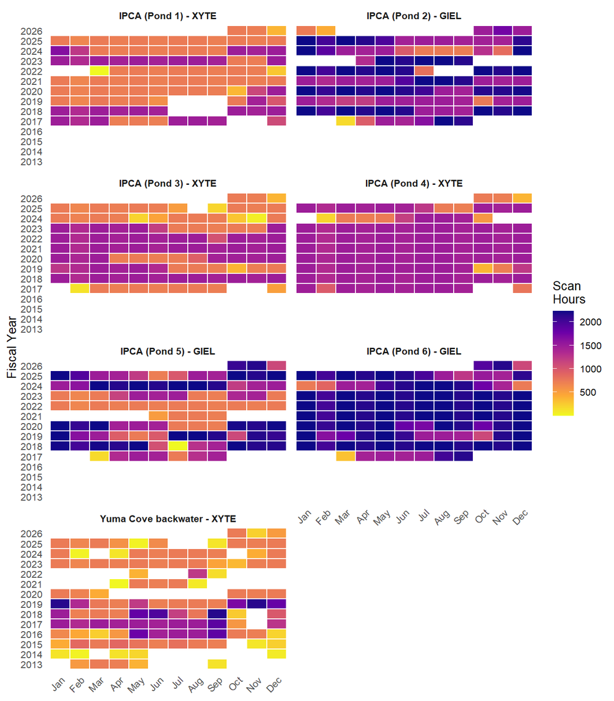

```r
SubEffort |>
  left_join(LocationLabels, by = "Location") |>
  group_by(LocationLabel, ScanFY, ScanMonth, ScanMonthName) |>
  summarise(TotalHrs = sum(SubEffortHrs, na.rm = TRUE), .groups = "drop") |>
  ggplot(aes(x = ScanMonthName, y = factor(ScanFY), fill = TotalHrs)) +
  geom_tile(color = "white", linewidth = 0.4) +
  scale_fill_viridis_c(name = "Scan\nHours", option = "plasma",
                       direction = -1, na.value = "grey92") +
  facet_wrap(~LocationLabel, ncol = 2) +
  labs(x = NULL, y = "Fiscal Year") +
  theme_minimal(base_size = 10) +
  theme(axis.text.x = element_text(angle = 45, hjust = 1),
        strip.text  = element_text(face = "bold"),
        panel.grid  = element_blank())
```

## Monthly Detection Probability

### Calculation

For each location and calendar month with reliable effort, monthly detection probability is:

$$p_{detection} = \frac{\text{confirmed-alive fish detected at least once
(by any reliable EID)}}{\text{confirmed-alive fish in population}}$$

The confirmed-alive population for month $m$ consists of all fish satisfying: `first_date` $\leq$ `MonthStart` $\leq$ `MaxScanDate` and `Survived = 1`.

Contacts are restricted to reliable EIDs and to fish in the confirmed-alive pool; each fish is counted at most once per month regardless of how many contacts it generated. Location-months with fewer than five confirmed-alive fish are excluded.

```r
# Location-months present in reliable effort
MonthlyPeriods <- SubEffort |>
  distinct(Location, MonthStart)

# Confirmed-alive fish per location-month
KnownAliveMonthly <- MonthlyPeriods |>
  left_join(
    StudyBWAnalysis |>
      filter(Survived == 1) |>
      select(Location = location, PITIndex, first_date, MaxScanDate),
    by = join_by(Location, MonthStart >= first_date, MonthStart <= MaxScanDate)
  ) |>
  group_by(Location, MonthStart) |>
  summarise(KnownAlive = n_distinct(PITIndex, na.rm = TRUE), .groups = "drop")

# Contacts restricted to reliable EIDs and confirmed-alive fish;
# deduplicated to one detection per fish per location-month
KnownAliveContacts <- StudyBWContacts |>
  filter(!is.na(PITIndex)) |>
  inner_join(ReliableEIDs, by = "EID") |>
  mutate(MonthStart = floor_date(Date, "month")) |>
  inner_join(
    StudyBWAnalysis |>
      filter(Survived == 1) |>
      select(Location = location, PITIndex, first_date, MaxScanDate),
    by = join_by(Backwater == Location, PITIndex,
                 MonthStart >= first_date, MonthStart <= MaxScanDate)
  ) |>
  distinct(Backwater, MonthStart, PITIndex) |>
  count(Backwater, MonthStart, name = "Detected") |>
  rename(Location = Backwater)

# Monthly detection probability
MonthlyDetection <- KnownAliveMonthly |>
  left_join(KnownAliveContacts, by = c("Location", "MonthStart")) |>
  mutate(
    Detected      = coalesce(Detected, 0L),
    DetectionRate = Detected / KnownAlive,
    CalMonth      = month(MonthStart),
    MonthName     = factor(format(MonthStart, "%b"), levels = month_levels),
    ScanFY        = as.integer(ifelse(CalMonth > 9,
                                      year(MonthStart) + 1,
                                      year(MonthStart)))
  ) |>
  filter(KnownAlive >= 5)
```

### Seasonal Pattern

Average monthly detection probability, pooled across all fiscal years, reveals the typical seasonal cycle. High detection probability months indicate periods when fish are active and moving past antennas; low probability months reflect reduced activity, shorter deployments, or both.

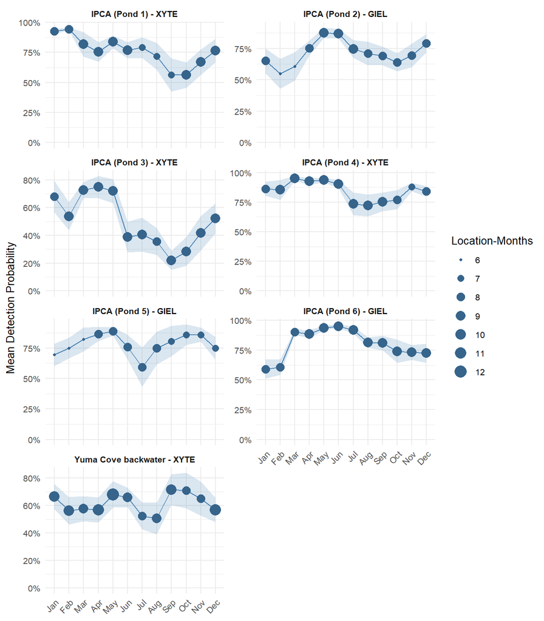

Mean monthly detection probability (proportion of confirmed-alive fish contacted at least once by any reliable scanner) by location, pooled across fiscal years. Points are sized by the number of location-months contributing to each mean; ribbons show ±1 SE.

```r
MonthlyDetectionSummary <- MonthlyDetection |>
  left_join(LocationLabels, by = "Location") |>
  group_by(Location, LocationLabel, CalMonth, MonthName) |>
  summarise(
    MeanDetection = mean(DetectionRate, na.rm = TRUE),
    SE            = sd(DetectionRate,   na.rm = TRUE) / sqrt(n()),
    N             = n(),
    .groups       = "drop"
  )

ggplot(MonthlyDetectionSummary,
       aes(x = MonthName, y = MeanDetection, group = LocationLabel)) +
  geom_ribbon(aes(ymin = pmax(MeanDetection - SE, 0),
                  ymax = pmin(MeanDetection + SE, 1)),
              alpha = 0.2, fill = "steelblue") +
  geom_line(color = "steelblue") +
  geom_point(aes(size = N), color = "steelblue4") +
  scale_y_continuous(labels = percent_format(accuracy = 1),
                     limits = c(0, NA)) +
  scale_size_continuous(name = "Location-Months", range = c(1, 5)) +
  facet_wrap(~LocationLabel, ncol = 2, scales = "free_y") +
  labs(x = NULL, y = "Mean Detection Probability") +
  theme_minimal(base_size = 10) +
  theme(axis.text.x = element_text(angle = 45, hjust = 1),
        strip.text  = element_text(face = "bold"))
```

### Empirical Active Season Definition

Active months are those with mean detection probability above the location-specific median. This data-driven threshold avoids imposing a pre-specified season and lets the contact pattern determine the activity calendar for each location.

```r
ActiveMonthFlags <- MonthlyDetectionSummary |>
  group_by(Location) |>
  mutate(MedianDetection = median(MeanDetection, na.rm = TRUE),
         ActiveSeason    = MeanDetection > MedianDetection) |>
  ungroup()

ActiveMonthFlags |>
  filter(ActiveSeason) |>
  group_by(LocationLabel) |>
  summarise(
    `Active Months`           = paste(as.character(MonthName), collapse = ", "),
    `Median Threshold (Det.)` = percent(unique(MedianDetection), accuracy = 0.1),
    .groups = "drop"
  ) |>
  kable()
```

| LocationLabel | Active Months | Median Threshold (Det.) |
| --- | --- | --- |
| IPCA (Pond 1) - XYTE | Jan, Feb, Mar, May, Jun, Jul | 76.6% |
| IPCA (Pond 2) - GIEL | Apr, May, Jun, Jul, Aug, Dec | 70.3% |
| IPCA (Pond 3) - XYTE | Jan, Feb, Mar, Apr, May, Dec | 47.0% |
| IPCA (Pond 4) - XYTE | Jan, Mar, Apr, May, Jun, Nov | 85.8% |
| IPCA (Pond 5) - GIEL | Mar, Apr, May, Sep, Oct, Nov | 78.2% |
| IPCA (Pond 6) - GIEL | Mar, Apr, May, Jun, Jul, Aug | 81.2% |
| Yuma Cove backwater - XYTE | Jan, May, Jun, Sep, Oct, Nov | 61.3% |

## Per-Sub-Effort Detection

Each reliable deployment is analyzed at the monthly sub-effort level. For a given EID and calendar month, the confirmed-alive fish are those meeting the known-survivor criteria at the sub-effort start date. The numerator is the count of those specific fish detected by that EID within that calendar month. Sub-effort hours (`SubEffortHrs`) — the actual scanning time within the month — replace total deployment duration as the effort metric.

```r
SubEffortDetection <- SubEffort |>
  select(EID, Location, MonthStart, SubEffortHrs, ScanMonth, ScanMonthName) |>
  # Confirmed-alive fish for this location at sub-effort start
  left_join(
    StudyBWAnalysis |>
      filter(Survived == 1) |>
      select(Location = location, PITIndex, first_date, MaxScanDate),
    by = join_by(Location, MonthStart >= first_date, MonthStart <= MaxScanDate)
  ) |>
  # Was each confirmed-alive fish detected by this EID in this month?
  left_join(
    StudyBWContacts |>
      filter(!is.na(PITIndex)) |>
      mutate(MonthStart = floor_date(Date, "month")) |>
      distinct(EID, MonthStart, PITIndex) |>
      mutate(Detected = TRUE),
    by = c("EID", "MonthStart", "PITIndex")
  ) |>
  mutate(Detected = coalesce(Detected, FALSE)) |>
  group_by(EID, Location, MonthStart, SubEffortHrs, ScanMonth, ScanMonthName) |>
  summarise(KnownAlive = n_distinct(PITIndex, na.rm = TRUE),
            Detected   = sum(Detected),
            .groups    = "drop") |>
  filter(KnownAlive >= 5) |>
  mutate(DetectionRate = Detected / KnownAlive) |>
  left_join(
    ActiveMonthFlags |> select(Location, CalMonth, ActiveSeason),
    by = c("Location", "ScanMonth" = "CalMonth")
  ) |>
  mutate(
    ActiveSeason = coalesce(ActiveSeason, FALSE),
    SeasonLabel  = if_else(ActiveSeason, "Active Season", "Low-Activity Season")
  ) |>
  left_join(LocationLabels, by = "Location")
```

### Detection Rate by Month

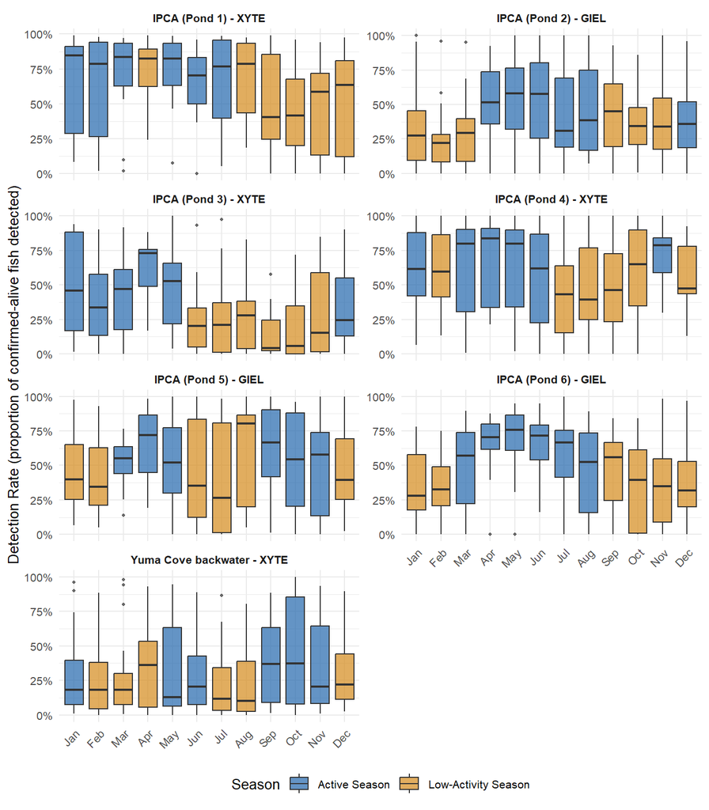

```r
season_colors <- c("Active Season"       = "#2166ac",
                   "Low-Activity Season" = "#d4891a")

ggplot(SubEffortDetection,
       aes(x = ScanMonthName, y = DetectionRate, fill = SeasonLabel)) +
  geom_boxplot(outlier.size = 0.8, alpha = 0.7, linewidth = 0.4) +
  scale_y_continuous(labels = percent_format(accuracy = 1),
                     limits = c(0, NA)) +
  scale_fill_manual(values = season_colors) +
  facet_wrap(~LocationLabel, ncol = 2, scales = "free_y") +
  labs(x = NULL,
       y = "Detection Rate (proportion of confirmed-alive fish detected)",
       fill = "Season") +
  theme_minimal(base_size = 10) +
  theme(axis.text.x     = element_text(angle = 45, hjust = 1),
        strip.text      = element_text(face = "bold"),
        legend.position = "bottom")
```

### Detection Rate vs. Sub-Effort Hours

Within a season, longer sub-efforts should contact a greater proportion of the confirmed-alive population, with diminishing returns as all active fish near the antenna are eventually detected. The sub-effort hours on the x-axis represent the actual scanning time within the calendar month, providing a consistent effort metric across both short partial-month sub-efforts and full-month sub-efforts.

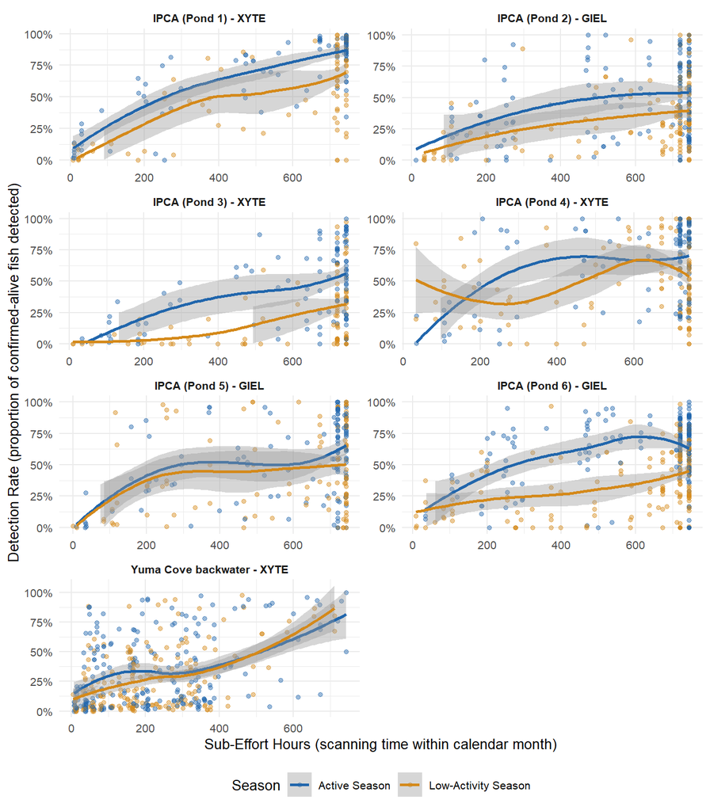

Per-sub-effort detection rate as a function of sub-effort hours (actual scanning time within the calendar month) by season. Smoothed loess trends with 95% confidence bands are shown. Active season sub-efforts typically achieve higher detection at equivalent scan hours.

```r
ggplot(SubEffortDetection |> filter(SubEffortHrs > 0),
       aes(x = SubEffortHrs, y = DetectionRate, color = SeasonLabel)) +
  geom_point(alpha = 0.45, size = 1.2) +
  geom_smooth(method = "loess", se = TRUE, linewidth = 0.9, span = 0.9) +
  scale_y_continuous(labels = percent_format(accuracy = 1),
                     limits = c(0, NA)) +
  scale_color_manual(values = season_colors) +
  facet_wrap(~LocationLabel, ncol = 2, scales = "free") +
  labs(x = "Sub-Effort Hours (scanning time within calendar month)",
       y = "Detection Rate (proportion of confirmed-alive fish detected)",
       color = "Season") +
  theme_minimal(base_size = 10) +
  theme(strip.text      = element_text(face = "bold"),
        legend.position = "bottom")
```

## Summary

```r
SubEffortDetection |>
  group_by(LocationLabel, SeasonLabel) |>
  summarise(
    N                   = n(),
    `Mean Sub-Eff. Hrs` = round(mean(SubEffortHrs,   na.rm = TRUE), 1),
    `Mean Known Alive`  = round(mean(KnownAlive),    0),
    `Mean Det. Rate`    = percent(mean(DetectionRate),   accuracy = 0.1),
    `Median Det. Rate`  = percent(median(DetectionRate), accuracy = 0.1),
    .groups = "drop"
  ) |>
  rename(Location = LocationLabel, Season = SeasonLabel) |>
  kable()
```

| Location | Season | N | Mean Sub-Eff. Hrs | Mean Known Alive | Mean Det. Rate | Median Det. Rate |
| --- | --- | --- | --- | --- | --- | --- |
| IPCA (Pond 1) - XYTE | Active Season | 92 | 521.1 | 150 | 67.5% | 81.3% |
| IPCA (Pond 1) - XYTE | Low-Activity Season | 84 | 559.9 | 136 | 54.1% | 58.6% |
| IPCA (Pond 2) - GIEL | Active Season | 153 | 584.5 | 97 | 48.3% | 46.2% |
| IPCA (Pond 2) - GIEL | Low-Activity Season | 131 | 589.8 | 99 | 33.9% | 28.6% |
| IPCA (Pond 3) - XYTE | Active Season | 103 | 591.6 | 165 | 45.3% | 45.1% |
| IPCA (Pond 3) - XYTE | Low-Activity Season | 88 | 596.4 | 145 | 23.7% | 15.0% |
| IPCA (Pond 4) - XYTE | Active Season | 117 | 604.4 | 141 | 63.7% | 76.7% |
| IPCA (Pond 4) - XYTE | Low-Activity Season | 115 | 593.7 | 124 | 52.8% | 50.7% |
| IPCA (Pond 5) - GIEL | Active Season | 119 | 584.6 | 118 | 55.1% | 56.3% |
| IPCA (Pond 5) - GIEL | Low-Activity Season | 111 | 567.7 | 108 | 45.7% | 36.6% |
| IPCA (Pond 6) - GIEL | Active Season | 182 | 594.9 | 115 | 60.6% | 69.0% |
| IPCA (Pond 6) - GIEL | Low-Activity Season | 175 | 578.3 | 112 | 36.5% | 34.6% |
| Yuma Cove backwater - XYTE | Active Season | 219 | 224.7 | 226 | 33.2% | 20.2% |
| Yuma Cove backwater - XYTE | Low-Activity Season | 209 | 210.9 | 214 | 26.4% | 18.0% |

## Tagged Fish Never Contacted by Passive Antennas

Fish tagged and released in study backwaters are expected to be detectable by passive PIT antennas whenever they move past an antenna array. A fish with zero passive antenna contacts despite an extended time at large raises a diagnostic question: was it genuinely absent (mortality or emigration), or did it persist undetected? Physical recapture or transfer of such a fish at a later date provides the clearest evidence that passive scanning failed for that individual.

Two categories of never-contacted fish are expected and unremarkable:

- **Fish tagged during physical capture events** — captured during electrofishing or netting, tagged on-site, and released the same day. These fish may have died or emigrated shortly after release with no opportunity for passive detection.
- **Fish tagged at the time of transfer** — fish transferred between locations with a new PIT tag applied during the transfer event, leaving no prior scanning window.

The diagnostic concern is fish tagged substantially earlier — at least one year before a subsequent physical encounter — that appear in a capture or transfer record with zero intervening passive antenna contacts.

```r
NeverScanned <- StudyBWAnalysis |>
  filter(contacts == 0) |>
  select(PITIndex, location, species, sex, total_length, first_date, event)

StudyBWAnalysis |>
  group_by(Location = location) |>
  summarise(
    `Total Tagged`    = n(),
    `Never Scanned`   = sum(contacts == 0),
    `  — Stocked`     = sum(contacts == 0 & event == "stocking"),
    `  — Captured`    = sum(contacts == 0 & event == "capture"),
    `% Never Scanned` = paste0(round(100 * sum(contacts == 0) / n(), 1), "%"),
    .groups = "drop"
  ) |>
  kable()
```

| Location | Total Tagged | Never Scanned | — Stocked | — Captured | % Never Scanned |
| --- | --- | --- | --- | --- | --- |
| IPCA (Pond 1) | 866 | 130 | 38 | 92 | 15% |
| IPCA (Pond 2) | 1456 | 238 | 37 | 201 | 16.3% |
| IPCA (Pond 3) | 1009 | 322 | 319 | 3 | 31.9% |
| IPCA (Pond 4) | 614 | 62 | 61 | 1 | 10.1% |
| IPCA (Pond 5) | 759 | 34 | 24 | 10 | 4.5% |
| IPCA (Pond 6) | 723 | 49 | 22 | 27 | 6.8% |
| Yuma Cove backwater | 3120 | 950 | 88 | 862 | 30.4% |

### Long-Absence Cases

Fish with zero passive antenna contacts that were physically re-encountered ≥365 days after tagging are the most diagnostically relevant — they confirm that a fish survived and remained accessible via physical means while evading all passive scanning during that period.

```r
SubsequentPhysical <- StudyBWNFWG |>
  filter(event %in% c("capture", "transfer"), FirstRecord == "no") |>
  inner_join(NeverScanned |> select(PITIndex, TagDate = first_date),
             by = "PITIndex") |>
  mutate(DaysAtLarge = as.integer(collection_date - TagDate)) |>
  filter(DaysAtLarge > 0) |>
  group_by(PITIndex) |>
  slice_max(DaysAtLarge, n = 1, with_ties = FALSE) |>
  ungroup()

LongAbsence <- NeverScanned |>
  inner_join(
    SubsequentPhysical |>
      select(PITIndex, ReencounterDate = collection_date,
             ReencounterEvent = event, DaysAtLarge),
    by = "PITIndex"
  ) |>
  filter(DaysAtLarge >= 365) |>
  select(PITIndex, Location = location, Species = species,
         TagDate = first_date, TagEvent = event,
         ReencounterDate, ReencounterEvent, DaysAtLarge) |>
  arrange(desc(DaysAtLarge))

if (nrow(LongAbsence) == 0) {
  cat("No never-scanned fish were physically re-encountered ≥365 days after tagging.")
} else {
  kable(LongAbsence)
}
```

| PITIndex | Location | Species | TagDate | TagEvent | ReencounterDate | ReencounterEvent | DaysAtLarge |
| --- | --- | --- | --- | --- | --- | --- | --- |
| 0015AC2962 | IPCA (Pond 6) | GIEL | 2017-03-21 | stocking | 2018-03-29 | capture | 373 |

```r
n_reencountered <- nrow(SubsequentPhysical)
n_long          <- nrow(LongAbsence)
n_never         <- nrow(NeverScanned)

cat(
  "
Of", n_never, "tagged fish with zero passive antenna contacts,",
  n_reencountered, "were subsequently re-encountered via physical capture or transfer.",
  if (n_long == 0) {
    "None had a re-encounter gap of ≥365 days, suggesting passive antenna detection is generally effective at registering fish that remain in the backwater long-term."
  } else {
    paste0(
      n_long,
      if (n_long == 1) " fish was" else " fish were",
      " re-encountered ≥365 days after tagging without any intervening passive contacts,",
      " confirming extended passive detection failure for those individuals.",
      " These cases are listed in the table above."
    )
  },
  "
"
)
```

Of 1785 tagged fish with zero passive antenna contacts, 3 were subsequently re-encountered via physical capture or transfer. 1 fish was re-encountered ≥365 days after tagging without any intervening passive contacts, confirming extended passive detection failure for those individuals. These cases are listed in the table above.

## Interpretation and Caveats

## Detection Rate vs. Absence

A low per-sub-effort detection rate does not indicate that undetected fish are absent or dead. It indicates that conditions during that period — season, scan duration, or fish behavior — were insufficient to contact all confirmed-alive fish. Survival analyses based on last-scan dates should be interpreted in light of whether meaningful effort from reliable scanners occurred after a fish’s last detection, and whether that effort fell during an active or low-activity season.

## Confirmed-Alive Population is a Minimum Count

The confirmed-alive denominator requires both a pre-period release date and a post-period confirmation scan. Fish that were genuinely alive during an assessment period but whose last scan preceded the period start are excluded from the denominator. This means detection rates may be slightly overestimated in early periods and underestimated near the most recent data where fewer fish have post-period confirmation scans.

## Reliability Exclusions

133 effort records were excluded due to discrepancies greater than 15% between `ScanTimeHrs` and `DeployedHrs`. Contacts associated with those records are also excluded from all detection analyses. Effort patterns and detection rates reflect only the 745 deployments where continuous operation could be assumed.